# Question 3 (Assignment 1) IE643

###### Author: [Jimut Bahan Pal (22D1594)](https://jimut123.github.io/)

# Solution to Question 3(a)

## Import required packages

```python
import numpy as np
import matplotlib.pyplot as plt
import random
import os
import seaborn as sns
# sns.set_style('dark', {"axes.facecolor": "black"})
sns.set_style("whitegrid")
```

```python
#seed random number generator of numpy for reproducibility
np.random.seed(7)
```

## Data Generation

1. Generate 100 two-dimensional data points from a 2D Gaussian distribution with mean [-2,-2] and covariance matrix of [[0.5 0],[0 0.5]]. Label data points as class +1. Consider this labeled data set as $D$. ($\textbf{Hint:}$ Use numpy.random.multivariate_normal)

```python
#Generate D_1

mean = [-2, -2]
cov = [[0.5, 0], [0, 0.5]]  # diagonal covariance
X1_X2_1 = np.random.multivariate_normal(mean, cov, 100)
Y_1 = np.array([1]*100)
```

```python
# create the dataset D1

D1 = []
for x1x2, y in zip(X1_X2_1, Y_1):
    D1.append([x1x2[0], x1x2[1], y])
print(len(D1))
print(D1[:10])
```

```
100
[[-0.8046178110726072, -2.329467474317652, 1], [-1.9767926397032205, -1.7118424728492332, 1], [-2.5578528233754887, -1.998539419391169, 1], [-2.000629597878016, -3.240777456129708, 1], [-1.280407123266566, -1.5753834273008287, 1], [-2.4422450686424404, -2.1213029387922555, 1], [-1.642699385976158, -…
```

2. Generate 100 two-dimensional data points from a 2D Gaussian distribution with mean [1,1] and covariance matrix of [[0.5 0],[0 0.5]]. Label data points as class -1. Consider this labeled data set as $D_2$.

```python
#Generate D_2

mean = [1, 1]
cov = [[0.5, 0], [0, 0.5]]  # diagonal covariance
X1_X2_2 = np.random.multivariate_normal(mean, cov, 100)
Y_2 = np.array([-1]*100)

# create the dataset D2
D2 = []
for x1x2, y in zip(X1_X2_2, Y_2):
    D2.append([x1x2[0], x1x2[1], y])
print(len(D2))
print(D2[:10])
```

```
100
[[-0.19034132356452282, 1.7177239438700214, -1], [-0.019325337411917554, 0.049911130370002055, -1], [0.7442618835743057, 1.5575569313547395, -1], [1.2122125778706245, 1.573299752851347, -1], [0.6862964389886099, 0.8782480304692944, -1], [0.19592286595169706, 0.7759422893024971, -1], [1.4194049382574…
```

3. Construct $D=D_1 \cup D_2$. Shuffle the data in $D$. (Hint: Use random.shuffle().)

```python
#Construct D and shuffle.
D = []
for item in D1:
    D.append(item)
for item in D2:
    D.append(item)

random.Random(4).shuffle(D)
# print("Shuffled list = ")
data = D
print(len(D))
```

```
200
```

#### Data Visualization

Write code to visualize the data $D$ you have generated. Use different colors for different classes. (Use matplotlib.pyplot.scatter to plot the points.)

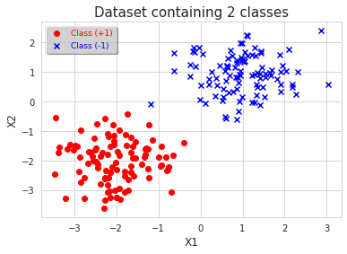

```python
def plot_data(data,plot_show=True):
    #write code to plot the data points. Use different colors for different classes.
    all_y1_x1 = []
    all_y1_x2 = []
    all_y2_x1 = []
    all_y2_x2 = []
    for data_points in data:
        x1, x2, y = data_points
        if y == 1:
            all_y1_x1.append(x1)
            all_y1_x2.append(x2)
        else:
            all_y2_x1.append(x1)
            all_y2_x2.append(x2)

    plt.scatter(all_y1_x1, all_y1_x2, color='red', marker='o')
    plt.scatter(all_y2_x1, all_y2_x2, color='blue', marker='x')
    plt.title("Dataset containing 2 classes",fontsize=15)
    plt.xlabel('X1',fontsize=12)
    plt.ylabel('X2',fontsize=12)
    plt.legend(['Class (+1)', 'Class (-1)'],frameon="True", fancybox="True", \
                       labelcolor=['red','blue'], shadow=True, prop={'size':9}, framealpha=0.5)
    if plot_show==True:
        plt.show()
plot_data(D)
```

## Perceptron prediction function

Write code to implement the prediction rule used in Perceptron. (Use the numpy function which helps in computing the dot product between two vectors.)

```python
def perceptron_prediction(w, x):
    # write code to compute the prediction for the example x using weight w
    dot_prod = np.dot(w, x)
    if dot_prod > 0:
        prediction = 1
    else:
        prediction = -1
    return prediction
```

## Function to update weights

Write code to implement the update rule for updating weights in perceptron learning algorithm. If there is a mistake in prediction made by perceptron, return is_mistake as True, otherwise return is_mistake as False.

```python
def perceptron_update_weights(w, x, y, y_pred):
    is_mistake = False
    #check for mistake and set is_mistake flag accordingly
    #and write code to update the weights in perceptron
    if y != y_pred:
        is_mistake = True
        w = w + y*x
    elif y == y_pred:
        w = w
        is_mistake = False
    return w, is_mistake
```

## Training procedure for perceptron

Complete the training procedure to train perceptron by adding appropriate code where required.

```python
epoch_list_perceptron = []
mistake_list_perceptron = []
def train_perceptron(data):
    #Initialize weights
    mu = 0
    sigma = 1
    w =  np.random.normal(mu, sigma, 3)  # gaussian distribution with zero mean and unit variance
    epochs = 0 #useful for executing multiple passes over a finite data set
    num_mistakes = 10 #some dummy value to get the while loop going
    max_epochs = 100
    while num_mistakes > 0 and epochs<max_epochs:   # until mistakes are not zero or number of epochs reach max_epochs
        num_mistakes = 0
        for i in range(len(data)):
            #retrieve the feature vector x from data set D
            x = np.array([data[i][0], data[i][1]])
            # Append an additional constant feature 1 to x
            x = np.append(x, 1)
            y_hat = perceptron_prediction(w, x)

            #retrieve the label y for x from data set D
            y = data[i][2]
            print(f"\r",end="")
            print("Epoch [{}/{}] : Prediction = {} Original = {} %".format(epochs,max_epochs,y_hat,y), end="")

            w, is_mistake = perceptron_update_weights(w, x, y, y_hat)

            if is_mistake:
                num_mistakes += 1
        mistake_list_perceptron.append(num_mistakes)
        epoch_list_perceptron.append(epochs)
        epochs=epochs+1
    return w
```

## Plotting the separating line

Write code to plot the separating line along with the data.

```python
def plot_data_with_separator(data, w, plot_show=False, save_file=False, save_no=0):
    #write required code. (You can reuse the code written for plotting the data points.)
    plot_data(data, plot_show=False)

    """Plot a line from slope and intercept"""
    axes = plt.gca()
    x_vals = np.array(axes.get_xlim())
    # x_vals = np.array([-4, 2])
    print(" = ",x_vals)
    y_vals = -(w[2]/w[1]) -(w[0]/w[1]) * x_vals
    print("Weights = ",w)
    print("Y values = ",y_vals)
    plt.plot(x_vals, y_vals, '--', color='yellow')
    if save_file == True:
        save_name = "percep_train_{}".format(save_no)
        plt.savefig(save_name)
    plt.show()
```

## Calling the Perceptron train function.

```python
w_final = train_perceptron(data)
```

```
Epoch [1/100] : Prediction = 1 Original = 1 %
```

## Calling the plot function to plot separator

```
 =  [-3.78390379  3.3472221 ]
Weights =  [-0.60347681 -2.15936733 -1.43170411]
Y values =  [ 0.39446464 -1.59846589]
```

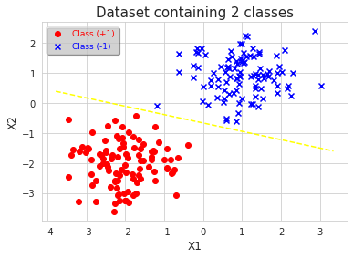

```python
plot_data_with_separator(data, w_final, plot_show=True)
```

## Number of mistakes vs Epochs

```python
epoch_list_perceptron.append(1)
mistake_list_perceptron.append(0)
```

```python
epoch_list_perceptron, mistake_list_perceptron
```

```
([0, 1, 1], [2, 0, 0])
```

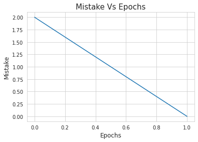

```python
plt.title("Mistake Vs Epochs",fontsize=15)
plt.ylabel('Mistake',fontsize=12)
plt.xlabel('Epochs',fontsize=12)
plt.plot(epoch_list_perceptron, mistake_list_perceptron)
```

# Solution to Question 3(b)(i) [T-perceptron]

```python
import math

def sigma_a(a):
    return (math.exp(2*a)-1)/(math.exp(2*a)+1)

def sigma_dash_a(a):
    return 4*math.exp(2*a)/(math.exp(2*a)+1)**2
```

```python
def t_perceptron_update_weights(w, x, y, y_pred, eeta):
    is_mistake = False
    #check for mistake and set is_mistake flag accordingly
    #and write code to update the weights in perceptron
    a = np.dot(w, x)
    if y != y_pred:
        is_mistake = True
        # w = w + y*x
        w = w + eeta*(y-sigma_a(a))*sigma_dash_a(a)*x
    elif y == y_pred:
        w = w
        is_mistake = False
    return w, is_mistake
```

```python
def t_perceptron_prediction(w, x):
    # write code to compute the prediction for the example x using weight w
    a = np.dot(w, x)
    sig_a = sigma_a(a)
    if sig_a > 0:
        prediction = 1
    else:
        prediction = -1
    return prediction
```

```python
def train_t_perceptron(data,eeta = 0.01):
    #Initialize weights
    epoch_list = []
    mistake_list = []
    mu = 0
    sigma = 1
    np.random.seed(7)
    w =  np.random.normal(mu, sigma, 3)  # gaussian distribution with zero mean and unit variance
    t = 0
    epochs = 0 #useful for executing multiple passes over a finite data set
    num_mistakes = 0 #some dummy value to get the while loop going
    max_epochs = 100
    while epochs<max_epochs:   # until mistakes are not zero or number of epochs reach max_epochs
        num_mistakes = 0
        for i in range(len(data)):
            #retrieve the feature vector x from data set D
            x = np.array([data[i][0], data[i][1]])
            # Append an additional constant feature 1 to x
            x = np.append(x, 1)
            y_hat = t_perceptron_prediction(w, x)

            #retrieve the label y for x from data set D
            y = data[i][2]

            w, is_mistake = t_perceptron_update_weights(w, x, y, y_hat, eeta)
            t += 1
            if is_mistake:
                num_mistakes += 1
        print(f"\r",end="")
        print("Epoch [{}/{}] : Prediction = {} Original = {} %".format(epochs,max_epochs,y_hat,y),end="")
        mistake_list.append(num_mistakes)
        epoch_list.append(epochs)
        epochs=epochs+1
    return w, epoch_list, mistake_list
```

# Solution to Question 3(b)(ii) [T-perceptron]

```python
w_final_eta1, epoch_list_eta1, mistake_list_eta1  = train_t_perceptron(data,eeta = 0.01)
epoch_list_eta1[:10], mistake_list_eta1[:10]
```

```
Epoch [99/100] : Prediction = 1 Original = 1 %
```

```
([0, 1, 2, 3, 4, 5, 6, 7, 8, 9], [110, 20, 7, 5, 4, 4, 3, 3, 3, 3])
```

```python
w_final_eta2, epoch_list_eta2, mistake_list_eta2  = train_t_perceptron(data,eeta = 0.001)
epoch_list_eta2[:10], mistake_list_eta2[:10]
```

```
Epoch [99/100] : Prediction = 1 Original = 1 %
```

```
([0, 1, 2, 3, 4, 5, 6, 7, 8, 9], [182, 177, 166, 145, 115, 95, 82, 65, 49, 41])
```

```python
w_final_eta3, epoch_list_eta3, mistake_list_eta3  = train_t_perceptron(data,eeta = 0.0001)
epoch_list_eta3[:10], mistake_list_eta3[:10]
```

```
Epoch [99/100] : Prediction = 1 Original = 1 %%
```

```
([0, 1, 2, 3, 4, 5, 6, 7, 8, 9],
 [184, 183, 183, 183, 183, 183, 183, 183, 181, 181])
```

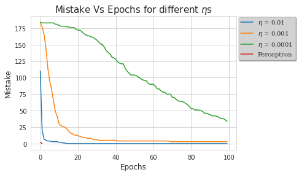

```python
# print("Graph ::")
plt.title("Mistake Vs Epochs for different $\eta$s",fontsize=15)
plt.ylabel('Mistake',fontsize=12)
plt.xlabel('Epochs',fontsize=12)
plt.plot(epoch_list_eta1, mistake_list_eta1)
plt.plot(epoch_list_eta2, mistake_list_eta2)
plt.plot(epoch_list_eta3, mistake_list_eta3)
plt.plot(epoch_list_perceptron, mistake_list_perceptron)
lgd = plt.legend([r'$\eta$ = 0.01',r'$\eta$ = 0.001', r'$\eta$ = 0.0001','Perceptron'], \
                 loc="lower right", prop={'family':'DejaVu Serif', 'size':10}, \
                 bbox_to_anchor=(1.3, 0.65), frameon="True", fancybox="True", \
                 shadow=True, framealpha=0.5)
plt.show()
```

#### We can see that the plot for perceptron cannot be seen due to the lower number of epoch and mistake made during training

# Solution to Question 3(b)(iii) [T-perceptron]

```python
def plot_data_with_separator_hyperplane(data, w, plot_show=False, save_file=False, save_no=0):
    #write required code. (You can reuse the code written for plotting the data points.)
    plot_data(data, plot_show=False)

    """Plot a line from slope and intercept"""

    axes = plt.gca()
    x_vals = np.array(axes.get_xlim())
    # x_vals = np.array([-4, 2])
    print(" = ",x_vals)
    y_vals = -(w[2]/w[1]) -(w[0]/w[1]) * x_vals
    print("Weights = ",w)
    print("Y values = ",y_vals)
    plt.plot(x_vals, y_vals, '--', color='black')

    # create a mesh to plot in
    x_min, x_max = x_vals.min() - 1, x_vals.max() + 1
    y_min, y_max = y_vals.min() - 1, y_vals.max() + 1
    xx2, yy2 = np.meshgrid(np.arange(x_min, x_max, .2),
                         np.arange(y_min, y_max, .2))
    # print(xx2)
    print("W = ",w)
    Z = []
    for x, y in zip(xx2.ravel(), yy2.ravel()):
        X = np.array([x,y])
        # Append an additional constant feature 1 to x
        X = np.append(X, 1)
        # print("x = ",X," prediction = ",t_perceptron_prediction(w, X))
        pred = t_perceptron_prediction(w, X)
        if pred == -1:
            pred = 0
        Z.append(pred)
    Z = np.array(Z)
    Z = Z.reshape(xx2.shape)
    plt.contourf(xx2, yy2, Z, cmap=plt.cm.PiYG, alpha=0.3)
    if save_file == True:
        save_name = "percep_train_{}".format(save_no)
        plt.savefig(save_name)
    plt.show()
```

#### Separating line obtained for T-perceptron with $\eta$ = 0.01

```
 =  [-3.78390379  3.3472221 ]
Weights =  [-0.13173373 -1.18023713 -0.63842208]
Y values =  [-0.11858152 -0.91453159]
W =  [-0.13173373 -1.18023713 -0.63842208]
```

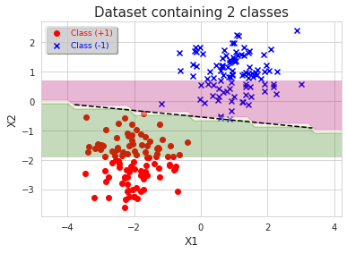

```python
plot_data_with_separator_hyperplane(data, w_final_eta1, plot_show=True)
```

#### Separating line obtained for T-perceptron with $\eta$ = 0.001

```
 =  [-3.78390379  3.3472221 ]
Weights =  [-0.07634433 -1.1974295  -0.53674492]
Y values =  [-0.20699785 -0.66165594]
W =  [-0.07634433 -1.1974295  -0.53674492]
```

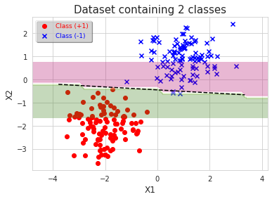

```python
plot_data_with_separator_hyperplane(data, w_final_eta2, plot_show=True)
```

#### Separating line obtained for T-perceptron with $\eta$ = 0.0001

```
 =  [-3.78390379  3.3472221 ]
Weights =  [ 0.62717207 -1.32004428 -0.06383809]
Y values =  [-1.84614782  1.54195292]
W =  [ 0.62717207 -1.32004428 -0.06383809]
```

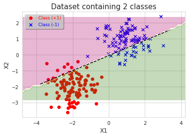

```python
plot_data_with_separator_hyperplane(data, w_final_eta3, plot_show=True)
```

#### Separating line obtained for perceptron

```
 =  [-3.78390379  3.3472221 ]
Weights =  [-0.60347681 -2.15936733 -1.43170411]
Y values =  [ 0.39446464 -1.59846589]
W =  [-0.60347681 -2.15936733 -1.43170411]
```

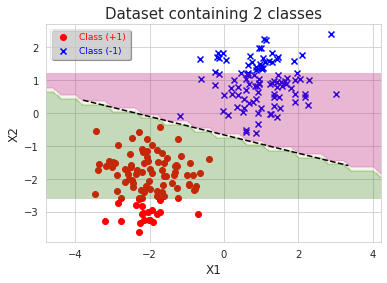

```python
plot_data_with_separator_hyperplane(data, w_final, plot_show=True)
```

### Observation: Perceptron perfectly separates the cluster into two separate hyperplanes. T-perceptron might not do that in the same number of epochs, we might change the learning rate $\eta$ for doing so. Hence the algorithm takes much longer time to converge.

# Solution to Question 3(c)

```python
#Generate D_1

mean = [-2, -2]
cov = [[2, 0], [0, 2]]  # diagonal covariance
X1_X2_1 = np.random.multivariate_normal(mean, cov, 100)
Y_1 = np.array([1]*100)
```

```python
# create the dataset D1

D1 = []
for x1x2, y in zip(X1_X2_1, Y_1):
    D1.append([x1x2[0], x1x2[1], y])
print(len(D1))
print(D1[:10])
```

```
100
[[-1.4236849456984664, -3.1157056467509774, 1], [-1.9970788387823377, -2.001259195756032, 1], [-4.481554912259416, -0.5608142465331318, 1], [-1.1507668546016574, -2.884490137284881, 1], [-2.242605877584511, -1.285398771952316, 1], [-2.369613786977241, -2.343299039312289, 1], [-4.055193714946709, -1.…
```

```python
#Generate D_2

mean = [1, 1]
cov = [[2, 0], [0, 2]]  # diagonal covariance
X1_X2_2 = np.random.multivariate_normal(mean, cov, 100)
Y_2 = np.array([-1]*100)
```

```python
# create the dataset D2
D2 = []
for x1x2, y in zip(X1_X2_2, Y_2):
    D2.append([x1x2[0], x1x2[1], y])
print(len(D2))
print(D2[:10])
```

```
100
[[-0.9001777392599959, 0.48852376714861134, -1], [2.115113862709479, 1.4244251557412488, -1], [2.146599505702694, 0.37259287797721985, -1], [0.7564960609385889, -0.6081542680966059, -1], [0.5518845786049942, 1.8388098765148424, -1], [0.5759790996884535, 1.6724013507787032, -1], [0.18926777849938448,…
```

```python
#Construct D and shuffle.
D = []
for item in D1:
    D.append(item)
for item in D2:
    D.append(item)

random.Random(4).shuffle(D)
# print("Shuffled list = ")
data = D
print(len(D))
```

```
200
```

### The data is not linearly separable

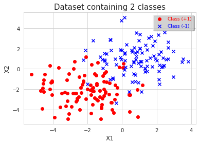

```python
plot_data(D)
```

## Perceptron training doesnot ends even after 100 epochs

```python
w_final = train_perceptron(data)
```

```
Epoch [99/100] : Prediction = 1 Original = 1 %
```

```
 =  [-5.68813623  4.25520336]
Weights =  [-2.41025818 -1.61941523 -1.61826901]
Y values =  [ 7.46665072 -7.33252813]
W =  [-2.41025818 -1.61941523 -1.61826901]
```

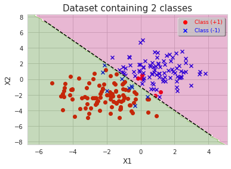

```python
plot_data_with_separator_hyperplane(data, w_final, plot_show=True)
```

```python
w_final_eta1, epoch_list_eta1, mistake_list_eta1  = train_t_perceptron(data,eeta = 0.01)
epoch_list_eta1[:10], mistake_list_eta1[:10]
```

```
Epoch [99/100] : Prediction = 1 Original = 1 %
```

```
([0, 1, 2, 3, 4, 5, 6, 7, 8, 9], [123, 72, 36, 26, 22, 20, 18, 18, 15, 14])
```

```
 =  [-5.68813623  4.25520336]
Weights =  [-0.01626963 -0.01445105 -0.00540127]
Y values =  [ 6.03019057 -5.16445823]
W =  [-0.01626963 -0.01445105 -0.00540127]
```

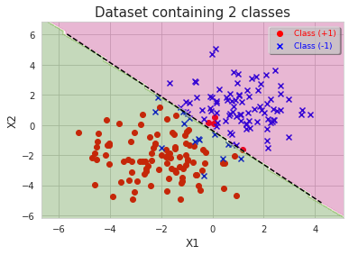

```python
plot_data_with_separator_hyperplane(data, w_final_eta1, plot_show=True)
```

```python
w_final_eta2, epoch_list_eta2, mistake_list_eta2  = train_t_perceptron(data,eeta = 0.001)
epoch_list_eta2[:10], mistake_list_eta2[:10]
```

```
Epoch [99/100] : Prediction = 1 Original = 1 %
```

```
([0, 1, 2, 3, 4, 5, 6, 7, 8, 9],
 [151, 145, 141, 134, 126, 125, 114, 106, 95, 93])
```

```
 =  [-5.68813623  4.25520336]
Weights =  [-0.37930639 -0.33626769 -0.39773063]
Y values =  [ 5.23337753 -5.98260405]
W =  [-0.37930639 -0.33626769 -0.39773063]
```

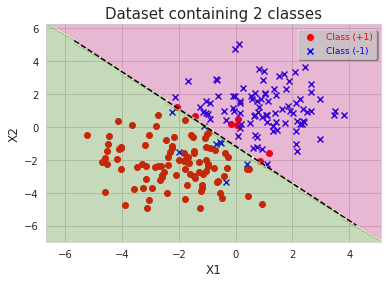

```python
plot_data_with_separator_hyperplane(data, w_final_eta2, plot_show=True)
```

```python
w_final_eta3, epoch_list_eta3, mistake_list_eta3  = train_t_perceptron(data,eeta = 0.0001)
epoch_list_eta3[:10], mistake_list_eta3[:10]
```

```
Epoch [99/100] : Prediction = 1 Original = 1 %%
```

```
([0, 1, 2, 3, 4, 5, 6, 7, 8, 9],
 [153, 153, 153, 153, 153, 150, 149, 148, 148, 148])
```

```
 =  [-5.68813623  4.25520336]
Weights =  [ 1.00640114 -1.15437323  0.03545976]
Y values =  [-4.92829085  3.74047246]
W =  [ 1.00640114 -1.15437323  0.03545976]
```

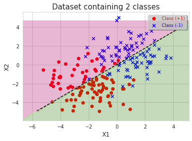

```python
plot_data_with_separator_hyperplane(data, w_final_eta3, plot_show=True)
```

## T-perceptron doesnot converges on any of the $\eta$ values provided

## T-perceptron is not useful for linearly non-separable data, in fact we need multi-layered perceptron for this stuff, if we need to overfit and classify the data properly. (Though this data is not linearly separable).

## References

1. P. Balamurugan, (2022), Deep Learning - Theory and Practice, IE 643, Lectures (2-5), IIT Bombay, last accessed on 03.10.2022.
2. https://stackoverflow.com/

## Acknowledgements

- [P Balamurugan](https://www.ieor.iitb.ac.in/balamurugan.palaniappan)
- [Akash Saha](https://www.linkedin.com/in/akash-saha-b820b149)